# p.362 #5 9.3

Sam Reeves

10/20/2021

> 5. Write a program to choose independently 25 numbers at random from $[0, 20]$, compute their sum $S_{25}$, and repeat this experiment 1000 times.

```r
experiment <- function(n, min, max, trials) {
  # Returns a vector of all the sums from n trials.
  experiment <- c()

  for (i in 1:trials) {
    experiment <- c(experiment, sum(runif(n, min, max)))
  }

  return(experiment)
}


S_25 <- experiment(25, 0, 20, 1000)
```

> Make a bar graph for the density of $S_{25}$ and compare it with the normal approximation of Exercise 4.

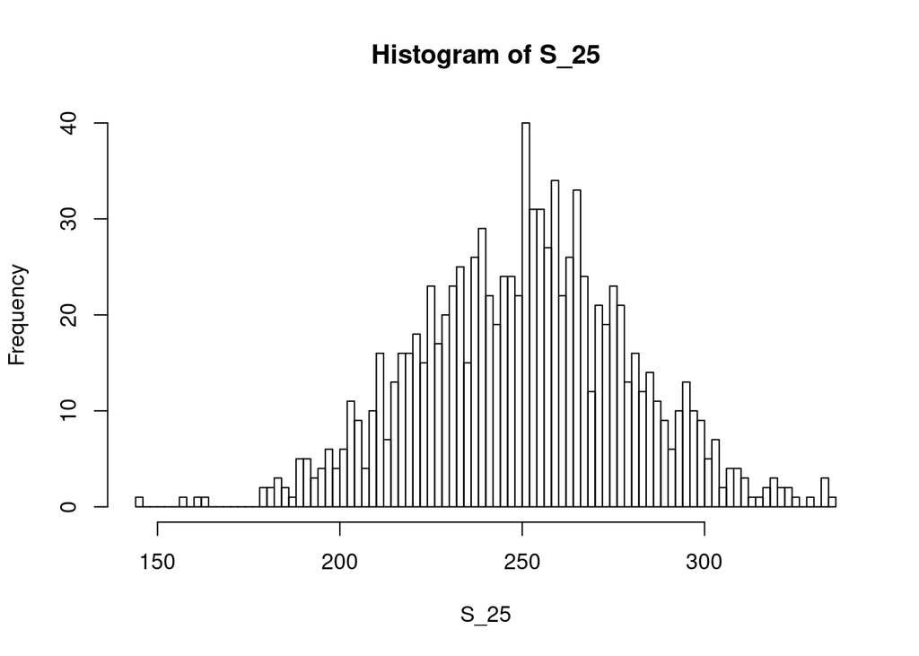

```r
hist(S_25, breaks = 100)
```

4. > Suppose we choose independently 25 numbers at random (uniform density) from the interval $[0, 20]$.

$$\mu = \frac{20 - 0}{2}$$
$$\sigma^2 = \frac{1}{12}(20 - 0)^2 = \frac{100}{3}$$
$$\lambda = \frac{1}{\mu} = \frac{1}{10}$$

```r
n <- 1000
mu <- 10
var <- 100/3
s_dev <- sqrt(var)
```

> Write the normal densities that approximate the densities of their sum $S_{25}$,

$$f_{S_n}(x) = \frac{\lambda e^{-\lambda x}(\lambda x)^{n-1}}{(n-1)!}$$

which can be approximated effectively with the normal distribution. We can test our function by making sure the density function equals 1.

```r
pdf_norm <- function(x, mu, sigma){
  1/(sqrt(2*pi*var))*exp(-(x - mu)^2/(2*var))
}

x <- seq(0, 20, length.out = 100)
y <- pdf_norm(x, mu, s_dev)

integrate(function(x) pdf_norm(x, mu, s_dev), mu-3*s_dev, mu+3*s_dev)
```

```
## 0.9973002 with absolute error < 9.3e-07
```

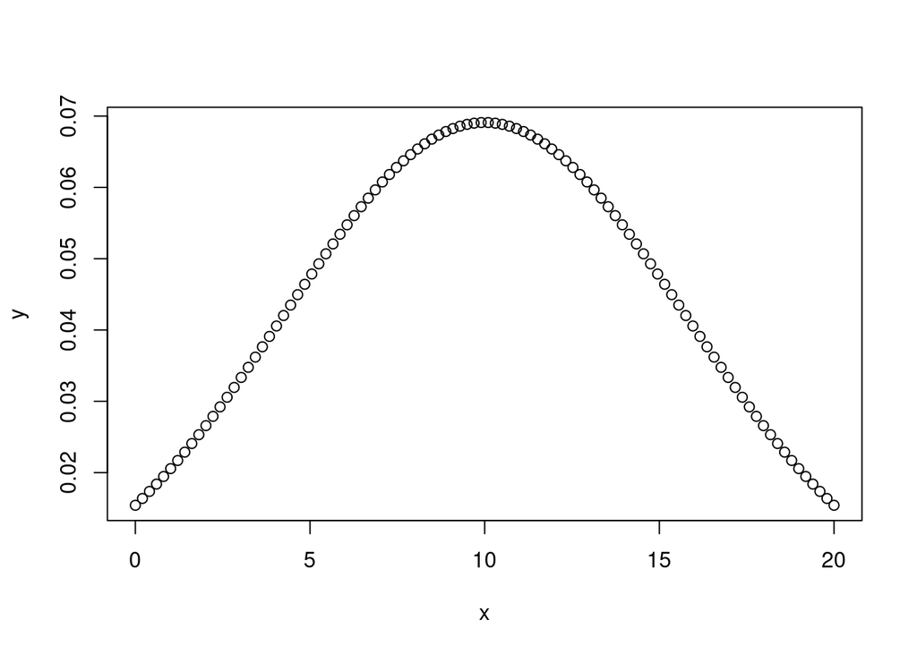

```r
plot(x, y)
```

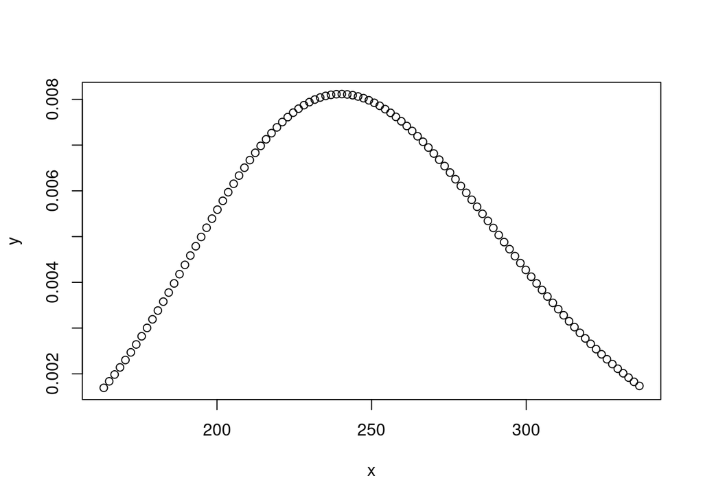

```r
simple_sum <- function(x, n, lam) {
  f_s_n <- (lam * exp(-lam * x) * (lam * x) ^ (n - 1)) / factorial(n-1)
  return(f_s_n)
}

n = 25
term <- 3 * sqrt(2500/3)

x <- seq(250 - term, 250 + term, length.out = 100)
y <- simple_sum(x, n, 1/mu)

plot(x, y)
```

> their standardized sum $S^{*}_{25}$,

$$f_{S^*_n}(x) = \frac{\sqrt{n}}{\lambda} f_{S_n}(\frac{\sqrt{n} x + n}{\lambda})$$

$$S^*_n = \frac{S_n-n \mu}{\sqrt{n} \sigma}$$

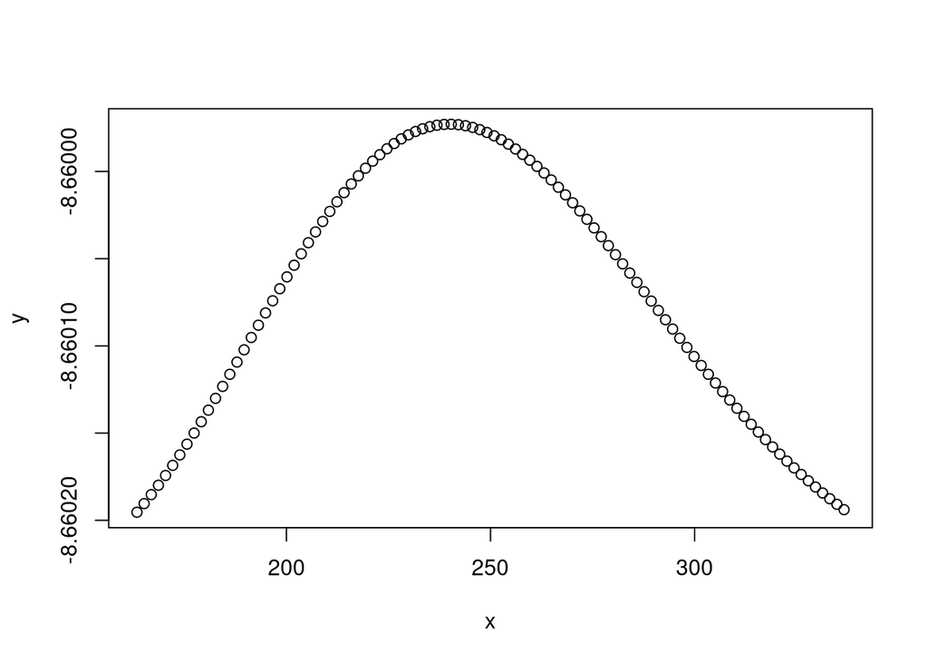

```r
st_sum <- function(x, n, mu, st_dev) {
  lam <- 1/mu
  s_star <- (simple_sum(x, n, lam) - n*mu) / (sqrt(n) * st_dev)
  return(s_star)
}

n <- 25
x <- seq(mu*25 - term, mu*25 + term, length = 100)
y <- st_sum(x, n, mu, s_dev)

plot(x, y)
```

or in a sample:

$$T^*_n = \frac{S_n - n \bar{\mu}}{\sqrt{n} \bar{\sigma}}$$

> and their average $A_{25}$.

$$\frac{1}{\sqrt{2 \pi}}\int^b_a e^{-x^2 / 2} dx$$

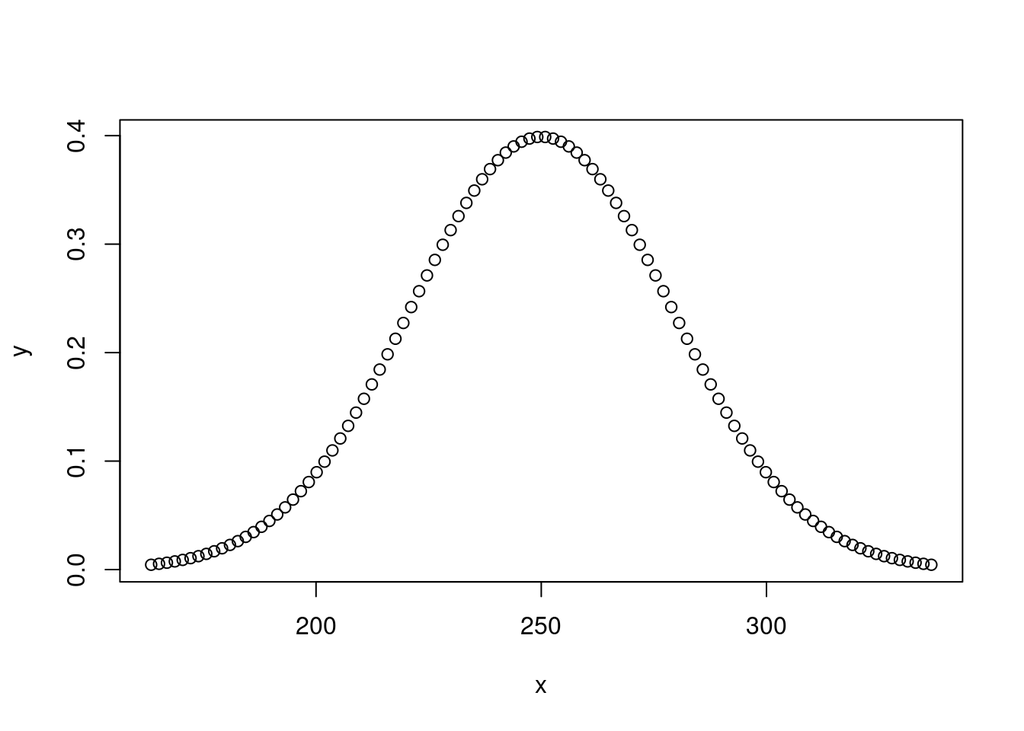

```r
samp_av <- function(x, mu, var) {
  av <- 1/sqrt(2*pi) * exp(-((x - mu) ^ 2) / (2 * var))

  return(av)
}


x <- seq(250 - term, 250 + term, length.out = 100)
y <- samp_av(x, 250, 2500/3)

plot(x, y)
```

This should equal the mean of a standard normal distribution…

> How good is the fit? Now do the same for the standardized sum $S^{*}_{25}$ and the average $A_{25}$.

The final average and the normal distribution are uncanny fits. The simple and standardized sums are a bit skew. But, so is the sample we took? These are very strong approximations for a sampling.